# Detecting Outlier Goal Scoring in the NHL

## Introduction

The purpose of this project is to build a machine learning model which uses data from https://moneypuck.com and, intuitively, attempts to learn how many goals a player "deserved" to score in a given season. This is in order to perform outlier detection. An "underperforming" player is a player who scored significantly less goals than the model predicted they should score, and an "overperforming" player would be a player who scored more goals than the model predicted.

It is important to note that this model is not predicting how many goals a player will score *next* season. Instead, the model is learning how many goals a player *should have scored this season*, and comparing this prediction with the number of goals the player *actually* scored.

From this, we will see that most players who are deemed as underperformers by the model do indeed have bounce back seasons (purely in terms of number of goals scored) the following year, and similarly most overperformers tend to score less goals the following year.

This type of model might be useful tool when trying to evaluate, say, the value of a player in a trade (e.g. selling high and buying low), negotiating contracts, or creating draft lists.

## Imports

```python
import os

import csv
%matplotlib inline
import sys

import matplotlib.pyplot as plt
import matplotlib.colors as mcolors
import numpy as np
import pandas as pd
import seaborn as sns
import xgboost as xgb
#import eli5
#import shap
from xgboost import XGBClassifier
from sklearn.feature_selection import RFE, RFECV
from sklearn.compose import ColumnTransformer, make_column_transformer
from sklearn.dummy import DummyClassifier
from sklearn.ensemble import RandomForestClassifier, RandomForestRegressor
from sklearn.impute import SimpleImputer
from sklearn.linear_model import LogisticRegression, Ridge, Lasso
from sklearn.neighbors import KNeighborsClassifier
from sklearn.tree import DecisionTreeClassifier
from sklearn.ensemble import StackingRegressor
from sklearn.metrics import (
    accuracy_score,
    ConfusionMatrixDisplay,
    classification_report,
    confusion_matrix,
    f1_score,
    make_scorer,
    plot_confusion_matrix,
    recall_score,
    mean_absolute_error
)
from sklearn.model_selection import (
    GridSearchCV,
    RandomizedSearchCV,
    cross_val_score,
    cross_validate,
    train_test_split,
)
from sklearn.pipeline import Pipeline, make_pipeline
from sklearn.preprocessing import OneHotEncoder, OrdinalEncoder, StandardScaler
from sklearn.svm import SVC, SVR
```

```python
# Load the data from each year into a dictionary
dfs = {}
for i in np.arange(10,22):
    year = str(i)+"_"+str(i+1)
    csv_name = "Players_"+year+".csv"
    dfs[year] = pd.read_csv(csv_name, index_col="playerId")
```

## Exploratory Data Analysis

```python
## Import the data dictionary which describes the data
#with open("MoneyPuckDataDictionaryForPlayers.csv", newline='') as csvfile:
#    r = csv.reader(csvfile, delimiter=',', quotechar='|')
#    for row in r:
#        print(''.join(row))
```

```python
# Descriptions of the features

pd.set_option('display.max_colwidth', None, "display.max_rows", None)
explanations = pd.read_csv("MoneyPuckDataDictionaryForPlayers.csv").drop(labels=range(25),axis=0)
renamed = {"*****MoneyPuck.com Player and Team Data******":"Column Name",
          "Unnamed: 1":"Description"}
explanations = explanations.rename(mapper=renamed, axis=1)
#explanations
```

```python
dfs["17_18"].head(5)
```

| playerId | season | name | team | position | situation | games_played | icetime | shifts | gameScore | onIce_xGoalsPercentage | ... | OffIce_F_xGoals | OffIce_A_xGoals | OffIce_F_shotAttempts | OffIce_A_shotAttempts | xGoalsForAfterShifts | xGoalsAgainstAfterShifts | corsiForAfterShifts | corsiAgainstAfterShifts | fenwickForAfterShifts | fenwickAgainstAfterShifts |
| --- | --- | --- | --- | --- | --- | --- | --- | --- | --- | --- | --- | --- | --- | --- | --- | --- | --- | --- | --- | --- | --- |
| 8479595 | 2017 | Blake Hillman | CHI | D | other | 4 | 70.0 | 2.0 | -0.13 | 0.00 | ... | 0.18 | 0.55 | 4.0 | 5.0 | 0.00 | 0.00 | 0.0 | 0.0 | 0.0 | 0.0 |
| 8479595 | 2017 | Blake Hillman | CHI | D | all | 4 | 4327.0 | 99.0 | 0.12 | 0.32 | ... | 5.12 | 8.86 | 153.0 | 185.0 | 0.00 | 0.00 | 0.0 | 0.0 | 0.0 | 0.0 |
| 8479595 | 2017 | Blake Hillman | CHI | D | 5on5 | 4 | 3860.0 | 84.0 | 0.12 | 0.37 | ... | 4.37 | 6.99 | 138.0 | 157.0 | 0.09 | 0.14 | 4.0 | 4.0 | 2.0 | 3.0 |
| 8479595 | 2017 | Blake Hillman | CHI | D | 4on5 | 4 | 392.0 | 12.0 | 0.12 | 0.02 | ... | 0.01 | 1.06 | 1.0 | 17.0 | 0.00 | 0.00 | 0.0 | 0.0 | 0.0 | 0.0 |
| 8479595 | 2017 | Blake Hillman | CHI | D | 5on4 | 4 | 5.0 | 1.0 | 0.03 | 0.00 | ... | 0.01 | 0.16 | 1.0 | 3.0 | 0.00 | 0.00 | 0.0 | 0.0 | 0.0 | 0.0 |

5 rows × 153 columns

```python
#dfs["17_18"].columns.tolist()
```

##### *Note:*

There are 153 of features here. Some of them we need to be careful with.

For example, the saved shots on goal feature must be dropped. The model scored extremely well on predicting goals, and upon further inspection, the largest positive coefficient identified by Ridge was shots on goal, while the largest negative coefficient was saved shots on goal. So the model essentially had learned something along the lines of goals = shots - saves shots, which means we were essentially giving it the answers.

```python
dfs["17_18"]["position"].value_counts()
```

```
D    1530
C    1365
L     860
R     695
Name: position, dtype: int64
```

```python
# Create a dataframe for all-situations scoring (as opposed to just 5 on 5, or 5 on 4, etc)
for key in dfs.keys():
    dfs[key] = dfs[key].loc[dfs[key]["situation"] == "all"].drop(columns="situation")
```

```python
#set back to default
pd.set_option('display.max_colwidth', 50, "display.max_rows", 60)
```

## Predicting Goals per Game

### Split the Data

```python
X_all_years = [dfs[key].drop(columns="I_F_goals") for key in dfs.keys()]
y_all_years = [dfs[key]["I_F_goals"] for key in dfs.keys()]
```

```python
def CreateXytrain(season_start="10_11", season_end="16_17"):

    start = int(season_start[:2])
    finish = int(season_end[:2])

    X = []
    y = []

    for i in np.arange(start,finish+1):

        dfX = X_all_years[i-start]

        playerid_new = {playerid: str(playerid)+"_"+str(i)+"_"+str(i+1) for playerid in list(dfX.index)}
        dfX = dfX.rename(index=playerid_new)
        X.append(dfX)

        dfy = y_all_years[i-start]
        dfy = dfy.rename(index=playerid_new)
        y.append(dfy)


    return pd.concat(X), pd.concat(y)
```

```python
# Seasons used as training data (i.e. "previous seaons")
season_start = "10_11"
season_end = "18_19"
X_train, y_train = CreateXytrain(season_start, season_end)

# Seasons used for predicting over/underperformers (i.e. "this year" and "next year")
this_season = "19_20"
next_season = "20_21"

playerid_this_season = {playerid: str(playerid)+"_"+this_season for playerid in list(dfs[this_season].index)}
X_this_season = dfs[this_season].drop(columns="I_F_goals").rename(index=playerid_this_season)
y_this_season = dfs[this_season]["I_F_goals"].rename(index=playerid_this_season)

playerid_next_season = {playerid: str(playerid)+"_"+next_season for playerid in list(dfs[next_season].index)}
X_next_season = dfs[next_season].drop(columns="I_F_goals").rename(index=playerid_next_season)
y_next_season = dfs[next_season]["I_F_goals"].rename(index=playerid_next_season)
```

```python
X_next_season.head()
```

| playerId | season | name | team | position | games_played | icetime | shifts | gameScore | onIce_xGoalsPercentage | offIce_xGoalsPercentage | ... | OffIce_F_xGoals | OffIce_A_xGoals | OffIce_F_shotAttempts | OffIce_A_shotAttempts | xGoalsForAfterShifts | xGoalsAgainstAfterShifts | corsiForAfterShifts | corsiAgainstAfterShifts | fenwickForAfterShifts | fenwickAgainstAfterShifts |
| --- | --- | --- | --- | --- | --- | --- | --- | --- | --- | --- | --- | --- | --- | --- | --- | --- | --- | --- | --- | --- | --- |
| 8470794_20_21 | 2020 | Joe Pavelski | DAL | C | 56 | 63932.0 | 1395.0 | 61.21 | 0.62 | 0.46 | ... | 82.79 | 96.97 | 1941.0 | 2131.0 | 0.0 | 0.0 | 0.0 | 0.0 | 0.0 | 0.0 |
| 8479514_20_21 | 2020 | Rem Pitlick | NSH | C | 10 | 6782.0 | 150.0 | 3.17 | 0.58 | 0.49 | ... | 21.18 | 21.89 | 412.0 | 450.0 | 0.0 | 0.0 | 0.0 | 0.0 | 0.0 | 0.0 |
| 8477948_20_21 | 2020 | Travis Sanheim | PHI | D | 55 | 72204.0 | 1595.0 | 23.38 | 0.48 | 0.49 | ... | 96.87 | 100.30 | 2003.0 | 1780.0 | 0.0 | 0.0 | 0.0 | 0.0 | 0.0 | 0.0 |
| 8480950_20_21 | 2020 | Ilya Lyubushkin | ARI | D | 42 | 39527.0 | 897.0 | 2.00 | 0.45 | 0.47 | ... | 85.16 | 96.06 | 1644.0 | 1712.0 | 0.0 | 0.0 | 0.0 | 0.0 | 0.0 | 0.0 |
| 8470144_20_21 | 2020 | Frans Nielsen | DET | C | 29 | 21035.0 | 496.0 | 3.81 | 0.37 | 0.48 | ... | 55.97 | 59.57 | 1170.0 | 1220.0 | 0.0 | 0.0 | 0.0 | 0.0 | 0.0 | 0.0 |

5 rows × 151 columns

# Create a preprocessor

```python
X_train.columns.tolist()
```

```
['season',
 'name',
 'team',
 'position',
 'games_played',
 'icetime',
 'shifts',
 'gameScore',
 'onIce_xGoalsPercentage',
 'offIce_xGoalsPercentage',
 'onIce_corsiPercentage',
 'offIce_corsiPercentage',
 'onIce_fenwickPercentage',
 'offIce_fenwickPercentage',
 'iceTimeRank',
 'I_F_xOnGoal',
 'I_F_xGoals',
 'I_F_xRebounds',
 'I_F_xFreeze',
 'I_F_xPlayStopped',
 'I_F_xPlayContinuedInZone',
 'I_F_xPlayContinuedOutsideZone',
 'I_F_flurryAdjustedxGoals',
 'I_F_scoreVenueAdjustedxGoals',
 'I_F_flurryScoreVenueAdjustedxGoals',
 'I_F_primaryAssists',
 'I_F_secondaryAssists',
 'I_F_shotsOnGoal',
 'I_F_missedShots',
 'I_F_blockedShotAttempts',
 'I_F_shotAttempts',
 'I_F_points',
 'I_F_rebounds',
 'I_F_reboundGoals',
 'I_F_freeze',
 'I_F_playStopped',
 'I_F_playContinuedInZone',
 'I_F_playContinuedOutsideZone',
 'I_F_savedShotsOnGoal',
 'I_F_savedUnblockedShotAttempts',
```

[output cut: 96 more lines]

```
 'OnIce_A_xGoalsFromActualReboundsOfShots',
 'OnIce_A_reboundxGoals',
 'OnIce_A_xGoals_with_earned_rebounds',
 'OnIce_A_xGoals_with_earned_rebounds_scoreAdjusted',
 'OnIce_A_xGoals_with_earned_rebounds_scoreFlurryAdjusted',
 'OffIce_F_xGoals',
 'OffIce_A_xGoals',
 'OffIce_F_shotAttempts',
 'OffIce_A_shotAttempts',
 'xGoalsForAfterShifts',
 'xGoalsAgainstAfterShifts',
 'corsiForAfterShifts',
 'corsiAgainstAfterShifts',
 'fenwickForAfterShifts',
 'fenwickAgainstAfterShifts']
```

```python
drop_features = ["season", "name", "I_F_primaryAssists", "I_F_secondaryAssists",
               'I_F_points', 'I_F_reboundGoals',
               'I_F_lowDangerGoals', 'I_F_mediumDangerGoals', 'I_F_highDangerGoals',
               'OnIce_F_goals', 'OnIce_F_reboundGoals',
               'OnIce_F_lowDangerGoals', 'OnIce_F_mediumDangerGoals', 'OnIce_F_highDangerGoals',
                "I_F_savedShotsOnGoal", "I_F_savedUnblockedShotAttempts"]


# get rid of all "on ice against" statistics
for feat in X_train.columns.tolist():
    if feat[:7] == "OnIce_A":
        drop_features.append(feat)


categorical_features = ["team", "position"]

pass_features = X_train.columns.tolist()
for feat in drop_features + categorical_features: #everything else is passed through
    pass_features.remove(feat)

# Create a column transformer
preprocessor = make_column_transformer((OneHotEncoder(handle_unknown = "ignore"), categorical_features),
                                       ("passthrough", pass_features),
                                       ("drop", drop_features))

# Note that we will apply standard scaler later in a pipeline

# Keep track of new feature names
new_categorical_features = []
for feat_name in X_train["team"].unique().tolist() + X_train["position"].unique().tolist():
    new_categorical_features.append(feat_name)

new_feature_names = new_categorical_features + pass_features
```

### Some Careful Feature Selection

```python
num_features = ['games_played', 'icetime',
                'gameScore',
                'onIce_corsiPercentage', 'onIce_fenwickPercentage',
                'I_F_primaryAssists', 'I_F_secondaryAssists', #
                'I_F_shotsOnGoal', 'I_F_missedShots', 'I_F_blockedShotAttempts', 'I_F_shotAttempts',
                'I_F_rebounds', 'I_F_freeze', 'I_F_playStopped',
                'I_F_playContinuedInZone', 'I_F_playContinuedOutsideZone',
                'I_F_hits', 'I_F_takeaways', 'I_F_giveaways', 'I_F_lowDangerShots', 'I_F_mediumDangerShots',
                'I_F_highDangerShots', 'I_F_scoreAdjustedShotsAttempts', 'I_F_unblockedShotAttempts', #
                'I_F_shifts',
                'I_F_oZoneShiftStarts', 'I_F_dZoneShiftStarts', 'I_F_neutralZoneShiftStarts',
                'I_F_flyShiftStarts', 'I_F_oZoneShiftEnds', 'I_F_dZoneShiftEnds', 'I_F_neutralZoneShiftEnds',
                'I_F_flyShiftEnds', 'faceoffsWon', 'faceoffsLost',
                'penalityMinutesDrawn', 'penaltiesDrawn', 'OnIce_F_shotsOnGoal', 'OnIce_F_missedShots', #
                'OnIce_F_blockedShotAttempts', 'OnIce_F_shotAttempts', 'OnIce_F_rebounds',
                'OnIce_F_lowDangerShots', 'OnIce_F_mediumDangerShots',
                'OnIce_F_highDangerShots',
                'OnIce_F_unblockedShotAttempts', 'corsiForAfterShifts',
                'corsiAgainstAfterShifts', 'fenwickForAfterShifts', 'fenwickAgainstAfterShifts']

drop_features = []
for feat in X_train.columns:
    if feat not in num_features+categorical_features:
        drop_features.append(feat)

preprocessor = make_column_transformer((OneHotEncoder(handle_unknown="ignore", sparse=False), categorical_features),
                                       (StandardScaler(), num_features),
                                       ("drop", drop_features))
```

```python
X_train_transformed = preprocessor.fit_transform(X_train)

ohe_column_names = preprocessor.named_transformers_["onehotencoder"].get_feature_names_out().tolist()#[0:51]

new_feature_names = ohe_column_names + num_features

pd.DataFrame(X_train_transformed, columns = new_feature_names).head()
```

|  | team_ANA | team_ARI | team_ATL | team_BOS | team_BUF | team_CAR | team_CBJ | team_CGY | team_CHI | team_COL | ... | OnIce_F_shotAttempts | OnIce_F_rebounds | OnIce_F_lowDangerShots | OnIce_F_mediumDangerShots | OnIce_F_highDangerShots | OnIce_F_unblockedShotAttempts | corsiForAfterShifts | corsiAgainstAfterShifts | fenwickForAfterShifts | fenwickAgainstAfterShifts |
| --- | --- | --- | --- | --- | --- | --- | --- | --- | --- | --- | --- | --- | --- | --- | --- | --- | --- | --- | --- | --- | --- |
| 0 | 0.0 | 0.0 | 0.0 | 0.0 | 0.0 | 0.0 | 0.0 | 0.0 | 0.0 | 0.0 | ... | 0.764728 | 0.621180 | 0.690739 | 1.016930 | 0.930066 | 0.775912 | 0.0 | 0.0 | 0.0 | 0.0 |
| 1 | 0.0 | 0.0 | 0.0 | 0.0 | 0.0 | 0.0 | 0.0 | 0.0 | 0.0 | 0.0 | ... | 0.633424 | 0.288426 | 0.724945 | 0.375619 | -0.075060 | 0.607091 | 0.0 | 0.0 | 0.0 | 0.0 |
| 2 | 0.0 | 0.0 | 0.0 | 0.0 | 0.0 | 0.0 | 0.0 | 0.0 | 0.0 | 0.0 | ... | 0.652428 | 0.496397 | 0.597449 | 0.803160 | 0.930066 | 0.664906 | 0.0 | 0.0 | 0.0 | 0.0 |
| 3 | 0.0 | 0.0 | 0.0 | 0.0 | 0.0 | 0.0 | 0.0 | 0.0 | 0.0 | 1.0 | ... | -0.667527 | -0.127516 | -0.612213 | -0.681355 | -0.477110 | -0.620903 | 0.0 | 0.0 | 0.0 | 0.0 |
| 4 | 0.0 | 0.0 | 0.0 | 0.0 | 0.0 | 0.0 | 0.0 | 0.0 | 0.0 | 0.0 | ... | 1.003150 | 0.662774 | 0.889757 | 1.100063 | 1.030579 | 0.947044 | 0.0 | 0.0 | 0.0 | 0.0 |

5 rows × 86 columns

### Create a Pipeline for Multiple Models

```python
# Lasso Regression
pipe_Lasso = make_pipeline(preprocessor, StandardScaler(), Lasso(max_iter=1000))

# Random forest regression
pipe_rfr = make_pipeline(preprocessor, RandomForestRegressor())

# SVM Regression
# Unfortunately my laptop is too slow to do hyperparameter optimization on svr but it is still giving
# decent results with a regularization strength of 1 and Gaussian RBF kernel
pipe_svr = make_pipeline(preprocessor, StandardScaler(), SVR(kernel="rbf", C=1.0))
```

### Support Vector Regressor

```python
pipe_svr = make_pipeline(preprocessor, StandardScaler(), SVR(kernel="rbf", C=1))
pd.DataFrame(cross_validate(pipe_svr, X_train, np.ravel(y_train), scoring="neg_mean_absolute_error"))
```

|  | fit_time | score_time | test_score |
| --- | --- | --- | --- |
| 0 | 6.270945 | 2.694465 | -1.783307 |
| 1 | 3.899914 | 2.185351 | -1.497802 |
| 2 | 4.312645 | 3.085737 | -1.792949 |
| 3 | 4.012335 | 3.454787 | -1.776908 |
| 4 | 5.911600 | 3.321434 | -2.240456 |

### Hyperparameter Tuning - Lasso

```python
# Lasso
parameters_lasso = {"lasso__alpha": np.linspace(0.1, 5, 100)} # Some values for the regularization strength
gs_lasso = GridSearchCV(
                            pipe_Lasso,
                            parameters_lasso,
                            scoring="neg_mean_absolute_error"
)
# I have an older laptop that doesn't take well to parallel processing so n_jobs is not -1 here for grid search!

gs_lasso.fit(X_train, y_train);
```

```python
alpha_best_lasso = gs_lasso.best_params_["lasso__alpha"]
alpha_best_lasso
```

```
0.1
```

```python
pd.DataFrame(gs_lasso.cv_results_).head(5)
```

|  | mean_fit_time | std_fit_time | mean_score_time | std_score_time | param_lasso__alpha | params | split0_test_score | split1_test_score | split2_test_score | split3_test_score | split4_test_score | mean_test_score | std_test_score | rank_test_score |
| --- | --- | --- | --- | --- | --- | --- | --- | --- | --- | --- | --- | --- | --- | --- |
| 0 | 0.225752 | 0.112055 | 0.014447 | 0.000905 | 0.1 | {'lasso__alpha': 0.1} | -1.669960 | -1.490207 | -1.778184 | -1.741666 | -1.948906 | -1.725785 | 0.149261 | 1 |
| 1 | 0.225628 | 0.149404 | 0.019601 | 0.007035 | 0.149495 | {'lasso__alpha': 0.14949494949494951} | -1.700759 | -1.523355 | -1.820505 | -1.789374 | -2.007210 | -1.768240 | 0.157992 | 2 |
| 2 | 0.111794 | 0.017819 | 0.015954 | 0.003293 | 0.19899 | {'lasso__alpha': 0.198989898989899} | -1.723200 | -1.547133 | -1.836347 | -1.805326 | -2.009458 | -1.784293 | 0.150883 | 8 |
| 3 | 0.110120 | 0.031454 | 0.017639 | 0.006400 | 0.248485 | {'lasso__alpha': 0.2484848484848485} | -1.722292 | -1.542244 | -1.830407 | -1.799147 | -2.008542 | -1.780526 | 0.151655 | 6 |
| 4 | 0.111249 | 0.006895 | 0.015867 | 0.003721 | 0.29798 | {'lasso__alpha': 0.297979797979798} | -1.721801 | -1.537456 | -1.826118 | -1.794510 | -2.009553 | -1.777888 | 0.153117 | 4 |

```python
pipe_Lasso = make_pipeline(preprocessor, StandardScaler(), Lasso(alpha = alpha_best_lasso))
pd.DataFrame(cross_validate(pipe_Lasso, X_train, y_train, scoring="neg_mean_absolute_error"))
```

|  | fit_time | score_time | test_score |
| --- | --- | --- | --- |
| 0 | 0.131518 | 0.016372 | -1.669960 |
| 1 | 0.122822 | 0.009946 | -1.490207 |
| 2 | 0.116655 | 0.012525 | -1.778184 |
| 3 | 0.121569 | 0.012058 | -1.741666 |
| 4 | 0.113411 | 0.008720 | -1.948906 |

```python
pipe_Lasso.fit(X_train, y_train)
new_feature_names[np.argmax(pipe_Lasso.named_steps["lasso"].coef_)]
```

```
'gameScore'
```

```python
new_feature_names[np.argmin(pipe_Lasso.named_steps["lasso"].coef_)]
```

```
'I_F_oZoneShiftEnds'
```

```python
sorted_coefs = np.sort(np.array(pipe_Lasso.named_steps["lasso"].coef_))
locs = np.argsort(np.array(pipe_Lasso.named_steps["lasso"].coef_))
for i, coef in enumerate(sorted_coefs):
    print(i)
    print("Feature:", new_feature_names[locs[i]])
    print("Coefficient:", coef)
    print("\n")
```

```
0
Feature: I_F_oZoneShiftEnds
Coefficient: -0.35541669171535367


1
Feature: OnIce_F_rebounds
Coefficient: -0.2689559558501741


2
Feature: I_F_rebounds
Coefficient: -0.23083732077844207


3
Feature: onIce_fenwickPercentage
Coefficient: -0.12697174297436423


4
Feature: team_L.A
Coefficient: -0.06372549162004947


5
Feature: team_S.J
Coefficient: -0.06013329150890731


6
Feature: team_CAR
Coefficient: -0.038295719998265566


7
Feature: I_F_dZoneShiftStarts
Coefficient: -0.03764305479416605


```

[output cut: 373 more lines]

```


83
Feature: I_F_highDangerShots
Coefficient: 2.293874566401487


84
Feature: I_F_mediumDangerShots
Coefficient: 2.7067386422415765


85
Feature: gameScore
Coefficient: 3.350083251724556
```

### Hyperparameter Tuning - Random Forest

```python
# Random Forest
d = preprocessor.fit_transform(X_train).shape[1]
parameters_rfr = {
                    "randomforestregressor__max_depth": np.arange(np.floor(np.sqrt(d)/2), np.floor(np.sqrt(d)*2)),
                    "randomforestregressor__n_estimators": np.arange(20,100)
                 }
                  #Some values for the regularization strength
rs_rfr = RandomizedSearchCV(
                            pipe_rfr,
                            parameters_rfr,
                            scoring = "neg_mean_absolute_error",
                            n_jobs=-1
)

rs_rfr.fit(X_train, np.ravel(y_train));
```

```python
max_depth_best = rs_rfr.best_params_["randomforestregressor__max_depth"]
n_estimators_best = rs_rfr.best_params_["randomforestregressor__n_estimators"]

print(max_depth_best)
print(n_estimators_best)
```

```
16.0
97
```

```python
pd.DataFrame(rs_rfr.cv_results_).head(5)
```

|  | mean_fit_time | std_fit_time | mean_score_time | std_score_time | param_randomforestregressor__n_estimators | param_randomforestregressor__max_depth | params | split0_test_score | split1_test_score | split2_test_score | split3_test_score | split4_test_score | mean_test_score | std_test_score | rank_test_score |
| --- | --- | --- | --- | --- | --- | --- | --- | --- | --- | --- | --- | --- | --- | --- | --- |
| 0 | 5.277317 | 0.062140 | 0.047767 | 0.008639 | 57 | 4 | {'randomforestregressor__n_estimators': 57, 'r... | -1.884765 | -1.652517 | -1.887395 | -1.948041 | -2.103867 | -1.895317 | 0.145189 | 10 |
| 1 | 2.605765 | 0.037900 | 0.040280 | 0.008504 | 27 | 4 | {'randomforestregressor__n_estimators': 27, 'r... | -1.862938 | -1.673069 | -1.890570 | -1.941168 | -2.105612 | -1.894671 | 0.139133 | 9 |
| 2 | 3.810558 | 0.092160 | 0.036631 | 0.007889 | 26 | 7 | {'randomforestregressor__n_estimators': 26, 'r... | -1.702228 | -1.498750 | -1.758279 | -1.742051 | -1.928858 | -1.726033 | 0.137593 | 3 |
| 3 | 5.601196 | 0.308259 | 0.050075 | 0.017581 | 62 | 4 | {'randomforestregressor__n_estimators': 62, 'r... | -1.860349 | -1.650417 | -1.882575 | -1.941639 | -2.097254 | -1.886447 | 0.144147 | 7 |
| 4 | 27.790071 | 1.985581 | 0.085476 | 0.022988 | 97 | 16 | {'randomforestregressor__n_estimators': 97, 'r... | -1.642654 | -1.441590 | -1.719947 | -1.686808 | -1.868530 | -1.671906 | 0.137907 | 1 |

```python
pipe_rfr = make_pipeline(preprocessor,
                                 StandardScaler(),
                                 RandomForestRegressor(max_depth = max_depth_best, n_estimators = n_estimators_best)
                                )
pd.DataFrame(cross_validate(pipe_rfr,
                            X_train,
                            np.ravel(y_train),
                            scoring="neg_mean_absolute_error"))
```

|  | fit_time | score_time | test_score |
| --- | --- | --- | --- |
| 0 | 13.140750 | 0.053228 | -1.638896 |
| 1 | 12.378179 | 0.043168 | -1.437019 |
| 2 | 19.130753 | 0.067946 | -1.717056 |
| 3 | 13.698088 | 0.112378 | -1.692225 |
| 4 | 16.187332 | 0.045746 | -1.878406 |

### Stacking Model

```python
sr_ridge = StackingRegressor(estimators = [("lasso", pipe_Lasso), ("rfr", pipe_rfr), ("svr", pipe_svr)],
                            final_estimator = Ridge(alpha=1))
```

```python
print("Using the stacking model")
np.mean(pd.DataFrame(cross_validate(sr_ridge, X_train, np.ravel(y_train), scoring = "neg_mean_absolute_error")))
```

```
Using the stacking model
```

```
fit_time      94.970235
score_time     2.473668
test_score    -1.661183
dtype: float64
```

```python
sr_ridge.fit(X_train, np.ravel(y_train));
```

```python
print("The stacking model coefficients are:")
sr_ridge.final_estimator_.coef_
```

```
The stacking model coefficients are:
```

```
array([0.35834428, 0.61233898, 0.04976671])
```

## Comparing Predicted Goals and Actual Goals

```python
def UnderPerformer(differences_last_year):

    underperformer_locs = np.argsort(differences_last_year)

    return underperformer_locs

def OverPerformer(differences_last_year):

    overperformer_locs = np.argsort(differences_last_year)[::-1] # Reversed order

    return overperformer_locs

# Requires a fitted model.
# Also, be careful that X_last_year is a subset of X_this_year,
# For example use X_last_year test and X_this_year entire dataset.
def Find(PerformerType,
         X_last_year,
         X_this_year,
         y_last_year,
         y_this_year,
         model,
         top_n = 10,
         print_details=True,
         produce_plot=True): # Decorator function

    perf_type = None
    season = str(X_last_year["season"].iloc[0])+"-"+str(X_last_year["season"].iloc[0]+1)
    future_season = str(X_last_year["season"].iloc[0]+1)+"-"+str(X_last_year["season"].iloc[0]+2)

    print("\n")
    if PerformerType == UnderPerformer:
        perf_type = "Underperformers"
    elif PerformerType == OverPerformer:
        perf_type = "Overperformers"
    else:
        print("Incorrect PerformerType.")

    print("-----------------------------------")
    print("Top", top_n, perf_type+" in "+season)


    # Differences in actual goals minus predicted goals for last year
    y_pred_last_year = model.predict(X_last_year)
    differences_last_year = np.ravel(y_last_year) - np.ravel(y_pred_last_year)

    # Sort the differences to identify under/overperformers.
    # Earlier in the list means more under/overperformance last season.
    performer_locs = PerformerType(differences_last_year)

    ly = []
    lyp = []
    ty = []
    typ = []
    names = []

    for i in range(top_n):

        # Get some info about the under/overperformer
        j = performer_locs[i]
        player_id_last_year = pd.DataFrame(y_last_year.iloc[j]).T.index[0]
        player_id_this_year = player_id_last_year[:7]+"_"+next_season

        name = pd.DataFrame(X_last_year.loc[player_id_last_year]).T["name"].iloc[0]

        # Find the games played, actual goals, and predicted goals from last year
        games_played_last_year = X_last_year["games_played"].loc[player_id_last_year]
        goals_last_year = y_last_year.loc[player_id_last_year][0]
        pred_goals_last_year = float(model.predict(pd.DataFrame(X_last_year.loc[player_id_last_year]).T)[0])

        # Make sure that player actually played next year
        if player_id_this_year in X_this_year.index.tolist():

            # Find the games played, actual goals, and predicted goals from this year
            games_played_this_year = X_this_year["games_played"].loc[player_id_this_year]
            goals_this_year = y_this_year.loc[player_id_this_year][0]
            pred_goals_this_year = float(model.predict(pd.DataFrame(X_this_year.loc[player_id_this_year]).T)[0])

            goal_pace_last_year = goals_last_year / games_played_last_year * 82
            pred_goals_last_year = pred_goals_last_year / games_played_last_year * 82
            goal_pace_this_year = goals_this_year / games_played_this_year * 82
            pred_goals_this_year = pred_goals_this_year / games_played_this_year * 82

            ly.append(goal_pace_last_year)
            lyp.append(pred_goals_last_year)
            ty.append(goal_pace_this_year)
            typ.append(pred_goals_this_year)
            names.append(name)

            if print_details:

                # Let's see if they actually bounced back next season!
                print("-----------------------------------")
                print("\n")

                print(i+1)
                print("Player:", name)
                print("Player ID:", player_id_this_year)
                print("\n")

                print(season+" Season")
                print("----------------------")
                print("Goal pace over 82 games: {:.2f}".format(goal_pace_last_year))
                print("Predicted goal pace over 82 games: {:.2f}".format(pred_goals_last_year))
                print("Games played:", games_played_last_year)
                print("\n")

                print(future_season+" Season")
                print("----------------------")
                print("Goal pace over 82 games: {:.2f}".format(goal_pace_this_year))
                print("Predicted goal pace over 82 games: {:.2f}".format(pred_goals_this_year))
                print("Games played:", games_played_this_year)
                print("\n")

        else:

            print("Player", name, "(player ID", player_id_this_year, ") did not play in the "+future_season+" season.\n\n")

    # Produce plot if desired
    if produce_plot:

        x = np.arange(np.max([10,top_n]))
        width = 0.4

        def CorrectColor(t):
            if t == 1:
                return "g"
            else:
                return "r"

        fig, ax = plt.subplots()
        if perf_type=="Overperformers":

            last_year = ax.bar(x - width/2, np.array(ly)-np.array(lyp), width, color="goldenrod",
                              bottom=lyp, label=season+" (Actual)")
            last_year_pred = ax.bar(x - width/2, lyp, width, alpha=0.7,
                                    color="seagreen", label=season+" (Predicted)")

            correctness = [val>0 for val in (np.array(ly)-np.array(ty))]

        elif perf_type=="Underperformers":

            last_year = ax.bar(x - width/2, ly, width, color="goldenrod",
                               label=season+" (Actual)")
            last_year_pred = ax.bar(x - width/2, np.array(lyp)-np.array(ly),
                                    width, bottom=ly, color="seagreen",
                                    alpha=0.7, label=season+" (Predicted)")

            correctness = [val<0 for val in (np.array(ly)-np.array(ty))]

        this_year = ax.bar(x + width/2, ty, width,
                           color="powderblue", label=future_season+" (Actual)")

        ax.set_ylabel('Goal Pace over 82 Games')

        plt.title("Top "+str(np.max([top_n,10]))+" "+perf_type+" of "+season)
        ax.set_xticks(x)
        ax.set_xticklabels(names)
        for i in range(len(x)):
            ax.get_xticklabels()[i].set_color(CorrectColor(correctness[i]))
        ax.legend()

        def labeler(graph):
            for bars in graph:
                height = bars.get_height()
                ax.annotate('{}'.format(round(height,1)),
                            xy=(bars.get_x() + bars.get_width() / 2, height/2),
                            xytext=(0,0),
                            textcoords="offset points",
                            ha='center', va='bottom')
        if perf_type=="Overperformers":
            for bars in zip(last_year, last_year_pred):
                height_ly = bars[0].get_height()
                height_lyp = bars[1].get_height()
                ax.annotate('{}'.format(round(height_ly+height_lyp,1)),
                            xy=(bars[0].get_x() + bars[0].get_width() / 2, height_ly/2+height_lyp),
                            xytext=(0,0),
                            textcoords="offset points",
                            ha='center', va='bottom')
            labeler(last_year_pred)

        elif perf_type=="Underperformers":
            for bars in zip(last_year, last_year_pred):
                height_ly = bars[0].get_height()
                height_lyp = bars[1].get_height()
                ax.annotate('{}'.format(round(height_ly+height_lyp,1)),
                            xy=(bars[0].get_x() + bars[0].get_width() / 2, height_ly+height_lyp/2),
                            xytext=(0,0),
                            textcoords="offset points",
                            ha='center', va='bottom')
            labeler(last_year)

        labeler(this_year)

        fig.set_size_inches(17, 5.5)
        fig.tight_layout()

        plt.show()
```

# Plotting The Results

This block of code finds the top $N$ overperformers and underperformers, and then creates a bar plot showing

1) The model's predicted number of goals scored that season (in green).

2) The actual number of goals scored that season (in gold).

3) The actual number of goals scored the following season (in light blue).

By default $N$ is set to 10, i.e. showing the top ten over/underperformers.

```
-----------------------------------
Top 10 Overperformers in 2019-2020
```

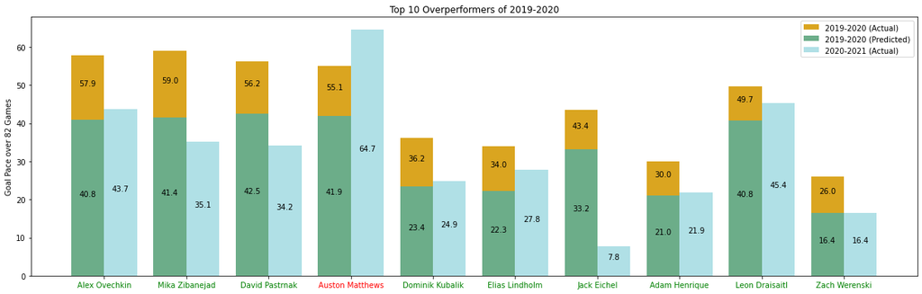

```python
Find(OverPerformer, X_this_season, X_next_season, pd.DataFrame(y_this_season), pd.DataFrame(y_next_season), sr_ridge, print_details=False)
```

```
-----------------------------------
Top 10 Underperformers in 2019-2020
```

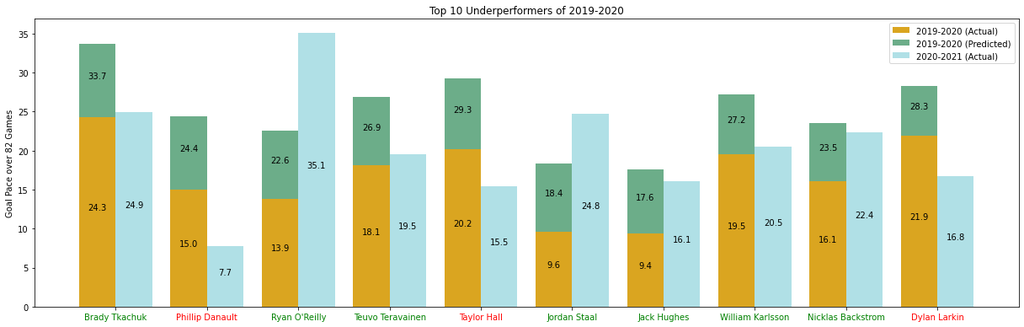

```python
Find(UnderPerformer, X_this_season, X_next_season, pd.DataFrame(y_this_season), pd.DataFrame(y_next_season), sr_ridge, print_details=False)
```